# QBUS2810 - Statistical Modelling for Business - 2023S2

## Individual Assignment (20%)

### SID: 520495548

**Important:** You must submit this Notebook in ***html*** and ***ipynb*** (raw) formats via Turnitin on Canvas. The *html* files are marked directly on Turnitin (for plagiarism and ChatGPT checking) and the raw Notebook (ipynb) files are used to validate your Python code in the *html* file.

**Step 1:** Rename the Notebook by replacing `123456` at the end of file name with your SID.  
**Step 2:** Provide your SID again by replacing `(provide your SID here)` with your SID.

## Task 1 (15 marks)

Conduct an appropriate exploratory data analysis on the house price, for all houses, including:

#### (a) Discuss any data cleaning you performed, including reasons for your decisions and the methods used, or reasons for not performing cleaning.

#### Answer:

First importing external libraries that will be used for the analysis.

```python
import pandas as pd                   # For data manipultion
import numpy as np                    # For linear algebra
import seaborn as sns                 # For plotting
import matplotlib.pyplot as plt       # For plotting
import statsmodels.api as sm          # For statisitical modelling
import statsmodels.formula.api as smf # For fitting regression models
import scipy.stats as stat            # To compute correlation between 2 vectors
from scipy.stats import rankdata     # calculates the ranks of any variable
from scipy.stats import median_test  # For median test
from scipy.stats import mannwhitneyu # For MW-U test
from scipy.stats import norm         # For calculations about normal distribution (pdf,cdf...)
from scipy.stats import ttest_ind    # For two-sample t-test
from sklearn.metrics import mean_squared_error
from statsmodels.stats.outliers_influence import variance_inflation_factor
```

Reading data for purpose of training from the file **'house_price_data_train.csv'**

```python
raw_data = pd.read_csv('house_price_data_train.csv')
raw_data.head(20)
```

|  | price | sqft | Bedrooms | Baths | Age | Occupancy | Pool | Fireplace | Waterfront | DOM |
| --- | --- | --- | --- | --- | --- | --- | --- | --- | --- | --- |
| 0 | 226000.0 | 3368 | 4 | 2 | 1 | 1 | No | 1 | 0 | 135 |
| 1 | 105800.0 | 2786 | 3 | 2 | 25 | 1 | No | 0 | 0 | 23 |
| 2 | 209100.0 | 3456 | 4 | 3 | 1 | 2 | No | 0 | 0 | 173 |
| 3 | 120000.0 | 2222 | 4 | 2 | 35 | 2 | No | 0 | 0 | 150 |
| 4 | 163500.0 | 2517 | 4 | 2 | 8 | 1 | No | 1 | 0 | 15 |
| 5 | 258000.0 | 4020 | 4 | 3 | 13 | 1 | No | 1 | 0 | 114 |
| 6 | 119900.0 | 1152 | 2 | 1 | 45 | 2 | No | 0 | 0 | 17 |
| 7 | 121300.0 | 1977 | 3 | 2 | 1 | 2 | No | 0 | 0 | 133 |
| 8 | 120000.0 | 3329 | 3 | 2 | 35 | 1 | No | 0 | 0 | 9 |
| 9 | 123400.0 | 2446 | 3 | 2 | 45 | 1 | No | 0 | 0 | 70 |
| 10 | NaN | 1714 | 3 | 2 | 13 | 1 | No | 1 | 0 | 9 |
| 11 | 154000.0 | 3250 | 3 | 2 | 25 | 2 | No | 1 | 0 | 34 |
| 12 | 68000.0 | 1342 | 3 | 1 | 35 | 2 | No | 0 | 0 | 380 |
| 13 | 141000.0 | 2703 | 3 | 2 | 25 | 1 | No | 1 | 0 | 39 |
| 14 | 60000.0 | 1336 | 3 | 1 | 35 | 2 | No | 0 | 0 | 42 |
| 15 | 121900.0 | 2200 | 3 | 2 | 25 | 1 | No | 1 | 0 | 26 |
| 16 | 135000.0 | 2135 | 3 | 2 | 25 | 2 | No | 1 | 0 | 46 |
| 17 | 118500.0 | 2550 | 4 | 2 | 35 | 1 | No | 0 | 0 | 124 |
| 18 | NaN | 2156 | 3 | 2 | 25 | 1 | No | 1 | 0 | 19 |
| 19 | 138900.0 | 2083 | 3 | 2 | 8 | 1 | No | 1 | 0 | 61 |

```python
data = raw_data.dropna().drop_duplicates()
data.columns = data.columns.str.lower()
data
```

|  | price | sqft | bedrooms | baths | age | occupancy | pool | fireplace | waterfront | dom |
| --- | --- | --- | --- | --- | --- | --- | --- | --- | --- | --- |
| 0 | 226000.0 | 3368 | 4 | 2 | 1 | 1 | No | 1 | 0 | 135 |
| 1 | 105800.0 | 2786 | 3 | 2 | 25 | 1 | No | 0 | 0 | 23 |
| 2 | 209100.0 | 3456 | 4 | 3 | 1 | 2 | No | 0 | 0 | 173 |
| 3 | 120000.0 | 2222 | 4 | 2 | 35 | 2 | No | 0 | 0 | 150 |
| 4 | 163500.0 | 2517 | 4 | 2 | 8 | 1 | No | 1 | 0 | 15 |
| ... | ... | ... | ... | ... | ... | ... | ... | ... | ... | ... |
| 995 | 201700.0 | 2856 | 4 | 3 | 1 | 2 | No | 1 | 1 | 316 |
| 996 | 24000.0 | 838 | 2 | 1 | 45 | 2 | No | 0 | 0 | 8 |
| 997 | 130000.0 | 2051 | 3 | 2 | 25 | 1 | No | 0 | 0 | 31 |
| 998 | 172000.0 | 2603 | 3 | 2 | 8 | 1 | No | 1 | 0 | 126 |
| 999 | 182000.0 | 2777 | 4 | 2 | 1 | 2 | No | 1 | 0 | 221 |

986 rows × 10 columns

#### Comment

After viewing the csv file, we can observe some missing values represented as **NaN** in the **price** column. Data incompleteness due to i.e. data entry error may affect the accuracy and reliability of the analysis later. Therefore, by using `dropna()` we can get rid of rows that have missing data. Additionally, there are some duplications of data in the dataset. Duplication may affect the quality of data and lead to unvalid result, which should be reduced using `drop_duplicates()`. Moreover, all columns in the dataset appear to have inconsistent form of naming. Thus, the use of `str.lower()` will convert all names to lower case to make it less complicated in mentioning columns' name.

#### (b) Examine the data types of all variables and consider appropriate data treatments for their usage in a linear regression model.

#### Answer:

Inspecting data type using `dtypes`

```python
data.loc[data['pool'] == 'No', 'pool'] = 0
data.loc[data['pool'] == 'Yes', 'pool'] = 1
```

```python
data['pool'] = data['pool'].astype(int)
```

```python
data.dtypes
```

```
price         float64
sqft            int64
bedrooms        int64
baths           int64
age             int64
occupancy       int64
pool            int64
fireplace       int64
waterfront      int64
dom             int64
dtype: object
```

#### Comment

- Data is kept in its original data type. Categorical variable includes: **occupancy, pool, fireplace and waterfront**. Numerical variables includes: **price, sqft, bedrooms, baths, age and dom**.
- The **pool** column is a categorical variable with Yes or No representation. In order to make it consistent with the pattern of other columns such as **occupancy**, **fireplace**, and **waterfront**, where data is represented as binary based on defined categories, I specify value in the **pool** columns as: No = 0 and Yes = 1. Moreover, I have also casted the **pool** column into type integer (befor it was of type object).

#### (c) Investigate potential relationships between all predictors and house prices. Utilize charts, correlation coefficients, hypothesis testing, and other tools to support your analysis. Based on your findings, identify the most and the least influential predictors for explaining house prices and provide statistical evidence to support your conclusion.

#### Answer:

#### Distribution of price

Distribution of price through histogram and boxplot

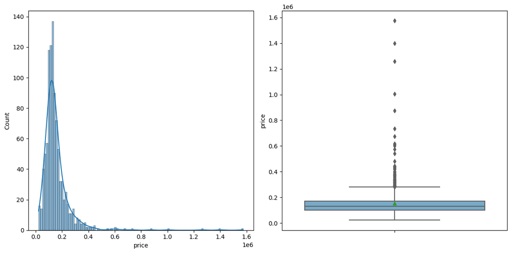

```python
fig, axs = plt.subplots(1, 2, figsize=(12, 6))

sns.histplot(data['price'], ax = axs[0], kde=True)

sns.boxplot(y='price', data=data, palette='Blues', showmeans=True, ax = axs[1])

plt.tight_layout()
plt.show()
```

```python
data['price'].describe().round()
```

```
count        986.0
mean      153976.0
std       112945.0
min        22000.0
25%       100000.0
50%       130000.0
75%       172000.0
max      1575000.0
Name: price, dtype: float64
```

Adding a column called **logPrice** to the dataset. This column is calculated by taking the logarithm of the variable **price**

```python
data['logPrice'] = np.log(data['price'])
data.head()
```

|  | price | sqft | bedrooms | baths | age | occupancy | pool | fireplace | waterfront | dom | logPrice |
| --- | --- | --- | --- | --- | --- | --- | --- | --- | --- | --- | --- |
| 0 | 226000.0 | 3368 | 4 | 2 | 1 | 1 | 0 | 1 | 0 | 135 | 12.328290 |
| 1 | 105800.0 | 2786 | 3 | 2 | 25 | 1 | 0 | 0 | 0 | 23 | 11.569306 |
| 2 | 209100.0 | 3456 | 4 | 3 | 1 | 2 | 0 | 0 | 0 | 173 | 12.250568 |
| 3 | 120000.0 | 2222 | 4 | 2 | 35 | 2 | 0 | 0 | 0 | 150 | 11.695247 |
| 4 | 163500.0 | 2517 | 4 | 2 | 8 | 1 | 0 | 1 | 0 | 15 | 12.004568 |

```python
table = data[['price', 'logPrice']].describe()
table.loc['Skew', :]=data[['price', 'logPrice']].skew()
table.loc['Kurt', :]=data[['price', 'logPrice']].kurt()
table.round(2)
```

|  | price | logPrice |
| --- | --- | --- |
| count | 986.00 | 986.00 |
| mean | 153975.64 | 11.80 |
| std | 112945.14 | 0.52 |
| min | 22000.00 | 10.00 |
| 25% | 100000.00 | 11.51 |
| 50% | 130000.00 | 11.78 |
| 75% | 172000.00 | 12.06 |
| max | 1575000.00 | 14.27 |
| Skew | 5.85 | 0.24 |
| Kurt | 55.27 | 2.35 |

Comparison between the distribution of price and logPrice through historgram

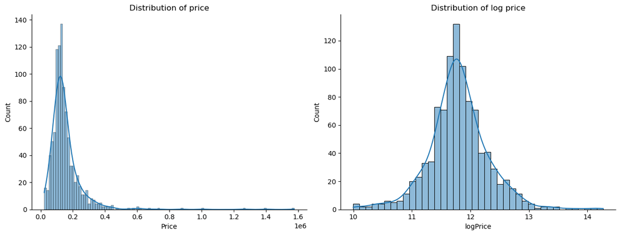

```python
fig, ax = plt.subplots(1,2,figsize=(13,5))

sns.histplot(data=data, x='price', ax=ax[0], kde=True)
ax[0].set_title('Distribution of price', fontsize=12)
ax[0].set_xlabel('Price')

sns.histplot(data=data, x='logPrice', ax=ax[1], kde=True)
ax[1].set_title('Distribution of log price', fontsize=12)
ax[1].set_xlabel('logPrice')

sns.despine()
plt.tight_layout()
plt.show()
```

#### Relationship of logPrice and numerical variables

Scatter plot matrix are conducted to examine the linear relationship

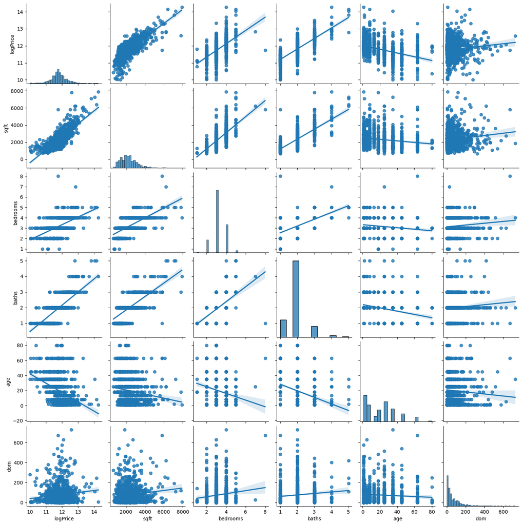

```python
sns.pairplot(data[['logPrice', 'sqft', 'bedrooms', 'baths', 'age', 'dom']], kind = 'reg')
plt.show()
```

Pearson correlation matrix to determine the strenth and the direction of a linear relationship

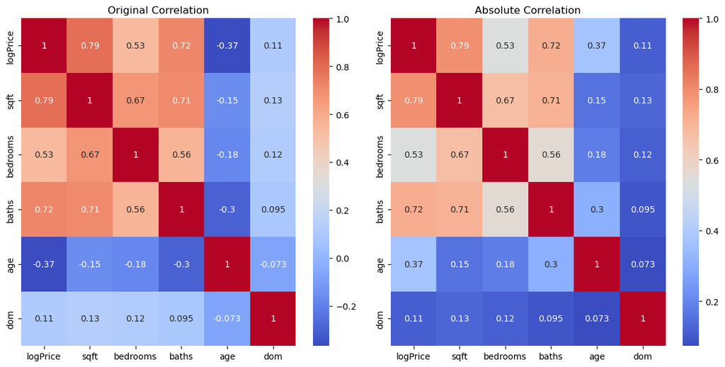

```python
original_corr = data[['logPrice', 'sqft', 'bedrooms', 'baths', 'age', 'dom']].corr()
abs_corr = original_corr.abs()

fig, axs = plt.subplots(1, 2, figsize=(12, 6))

sns.heatmap(original_corr, annot=True, cmap='coolwarm', ax=axs[0])
axs[0].set_title("Original Correlation")

sns.heatmap(abs_corr, annot=True, cmap='coolwarm', ax=axs[1])
axs[1].set_title("Absolute Correlation")

plt.tight_layout()
plt.show()
```

The three most influential predictor on logPrice is sqft, baths and bedrooms.

Comparison of **price** and **logPrice** versus **sqft**

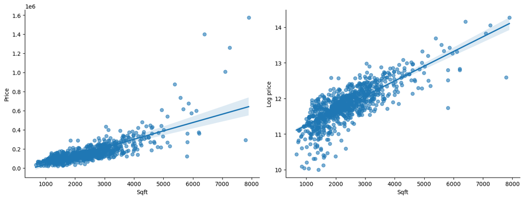

```python
fig, ax= plt.subplots(1,2, figsize=(13,5))

# Plot Price vs Sqft
sns.regplot(data=data, x='sqft', y='price', ax=ax[0], scatter_kws={'alpha':0.6})
ax[0].set_xlabel('Sqft')
ax[0].set_ylabel('Price')

# PLot logPrice vs Sqft
sns.regplot(data=data, x='sqft', y='logPrice', ax=ax[1], scatter_kws={'alpha':0.6})
ax[1].set_xlabel('Sqft')
ax[1].set_ylabel('Log price')

# Layout set up
sns.despine()
plt.tight_layout()
plt.show()
```

#### Relationship between logPrice and categorical variables

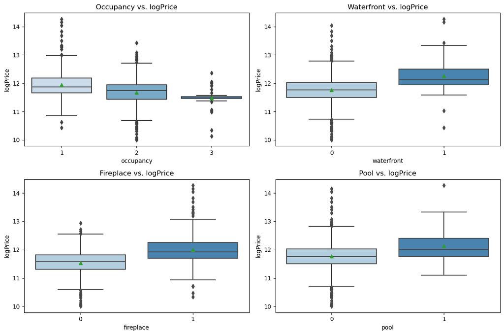

```python
fig, axes = plt.subplots(2, 2, figsize=(12, 8))

sns.boxplot(x='occupancy', y='logPrice', data=data, palette='Blues', showmeans=True, ax=axes[0, 0])
axes[0, 0].set_title('Occupancy vs. logPrice')

sns.boxplot(x='waterfront', y='logPrice', data=data, palette='Blues', showmeans=True, ax=axes[0, 1])
axes[0, 1].set_title('Waterfront vs. logPrice')

sns.boxplot(x='fireplace', y='logPrice', data=data, palette='Blues', showmeans=True, ax=axes[1, 0])
axes[1, 0].set_title('Fireplace vs. logPrice')

sns.boxplot(x='pool', y='logPrice', data=data, palette='Blues', showmeans=True, ax=axes[1, 1])
axes[1, 1].set_title('Pool vs. logPrice')

plt.tight_layout()
plt.show()
```

#### Comment

**Price vs. logPrice**

**Most and Least predictors**

- The most influential predictors for explaining house price is **sqft** - house living area in square meters. The larger the house, the more expensive. The Pearson correlation of 0.79 indicates strong linear relationship between these two variables. Analysis between **price** and **logPrice** versus **sqft** conducted through the scatter plot shows the benefit of log transformation where linear relationship is strengthened.
- The least influential predictors could be **dom** - days on the market. Based on the correlation matrix, the Pearson correlation between **logPrice** and **dom** is 0.11. This predictors does not seem to affect house price since longer or shorter days on the market does not point out anything. And customers tends to focus the functionalities rather than how long it is there.
- The scatter plots and correlation matrix from EDA points out strong relationship between **logPrice** and **sqft**, followed by **baths** and **bedrooms**.
- For categorical variables, the boxplot between **logPrice** and other variables does not seem to point out significant relationship since these variables just make the price cluster around the mean of **logPrice**.
  - *Occupancy*: Price is higher for houses with owner, followed by vacant and tenant. This could be due to the fact that owner-occupied house are often in good conditions. Owner might have invested in the maintenance the house, which can attract more customers.
  - *Waterfront*: Price is higher for houses with waterfront. This is due to the location of these houses, which are usually on market with higher price. Waterfront house offers buyers with scenic view and easy access to water activity or beach life.
  - *Fireplace and Pool*: Same observation as above, price is higher for houses with fireplace and pool. These two features are supposed to gurantee the comfort of the house. Buyers who are looking for a high quality life tend to put these criterias on the check list.

## Task 2 (15 marks)

- Conduct (with $\alpha=0.05$) the appropriate t-test, median and Mann-Whitney U tests, to assess whether houses prices are typically higher for houses with water front (the alternative of unequal prices is fine for the median test).
- Assess all assumptions made.
- Which test’s result do you believe the most? Discuss and explain.

Provide relevant analysis to support your answers.

#### Answer:

You can make multiple code cells (with intermediate comments) but only make final discussion in the `Comment` cell

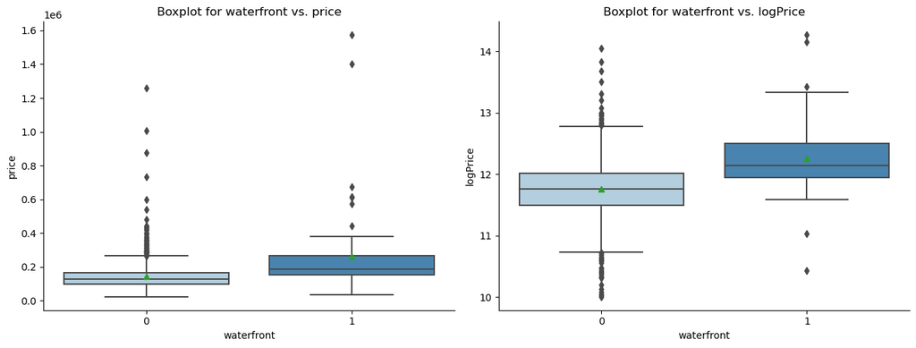

```python
fig, ax= plt.subplots(1,2, figsize=(13,5))

# Plot Price vs Sqft
sns.boxplot(x='waterfront', y='price', data=data, palette='Blues', showmeans=True, ax=ax[0])
ax[0].set_title('Boxplot for waterfront vs. price')

# PLot logPrice vs Sqft
sns.boxplot(x='waterfront', y='logPrice', data=data, palette='Blues', showmeans=True, ax=ax[1])
ax[1].set_title('Boxplot for waterfront vs. logPrice')

# Layout set up
sns.despine()
plt.tight_layout()
plt.show()
```

```python
P0 = data[data['waterfront']==0]
P1 = data[data['waterfront']==1]
```

```python
HousePrice_waterfront = pd.DataFrame({'No Waterfront':P0.price.describe(),
                                   'Waterfront':P1.price.describe()})
HousePrice_waterfront.round(2)
```

|  | No Waterfront | Waterfront |
| --- | --- | --- |
| count | 916.00 | 70.00 |
| mean | 145772.09 | 261325.00 |
| std | 90605.65 | 246286.99 |
| min | 22000.00 | 34000.00 |
| 25% | 98500.00 | 153125.00 |
| 50% | 127810.00 | 187500.00 |
| 75% | 165372.50 | 267500.00 |
| max | 1260000.00 | 1575000.00 |

#### Two sample t-test

```python
ttest_ind(P0.price, P1.price, equal_var = False)
```

```
Ttest_indResult(statistic=-3.905297448886061, pvalue=0.00021338179372696258)
```

Since the question asked for the comparison between price of house with/without waterfront, instead of using logPrice, I use the original price to point out the difference between two groups.

The hypotheses are:

$H_0:$ the two group means are equal: $\mu_{\text{no waterfront}} = \mu_{\text{waterfront}}$. $H_1:$ the two group means are not equal: $\mu_{\text{no waterfront}} < \mu_{\text{waterfront}}$.

We choose $\alpha=0.05$ as standard.

Assumptions:

- Data are i.i.d for each group: We assume this is true. Houses within with and without waterfront group are independent from each other, that is, house does not influence each other's price.
- Two groups are independent of each other: We assume that houses with waterfont do not affect the price of house without waterfront and vice versa.
- The 4th moment of price is finite: The boxplot of price and waterfront shows that there are quite a few outliers at the right tail. Hence, this assumption does not satisfy.

Thus, as long as the last assumption does not satisfy, the t-test for difference in means is not valid. Since the 4th moment assumption does not satisfy, we might find the usefulness of log transformation of price, which can be used for model in below tasks.

#### Median test

```python
median_test(P0.price, P1.price, ties = "ignore")
```

```
(39.68854775470324,
 2.978670543157528e-10,
 130000.0,
 array([[429,  61],
        [478,   9]]))
```

The hypotheses are:

$H_0: \text{median}_\text{no waterfront} = \text{median}_\text{waterfront}$ vs $H_1: \text{median}_\text{no waterfront} \neq \text{median}_\text{waterfront}$.

We choose $\alpha = 0.05$ as standard and consistency across different tests.

The test statistic is $39.689$, which under the null follows a $\chi^2_1$ distribution. In this case, the p-value is is $P(\chi^2_1 > 39.689) = 2.979 \times 10^{-10}$. Since, the p-value is much less than $< 0.05$, we reject the null hypothesis and conclude that there is a significant difference in median between $price$ for houses without waterfront and with waterfront.

Assumptions made include:

Thus, since all assumptions are satisfied, the median test is valid.

### Mann-Whitney U test

```python
mannwhitneyu(P0.price, P1.price, alternative='less')
```

```
MannwhitneyuResult(statistic=14843.5, pvalue=3.2709598038888467e-14)
```

The hypotheses are:

$H_0:$ $price$ in group without waterfront has the same distribution as $price$ in group with waterfront: $P(P_0 > P_1) = 0.5$; vs

$H_1:$ $price$ in group without waterfront does not have the same distribution as $price$ in group with waterfront: $P(P_0 > P_1) < 0.5$.

We choose $\alpha = 0.05$ as standard and consistency across different tests.

The assumptions made are:

1. Data are i.i.d. in each group: We assume this is true. Houses within with and without waterfront group are independent from each other, that is, house does not influence each other's price.
2. Independence of the two groups: We assume that houses with waterfont do not affect the price of house without waterfront and vice versa.
3. Each group's sample size is large enough for the CLT to work: Our dataset is quite large with total observations is 986.
4. Data are at least on the ordinal scale: price is a numerical variable, so this is satisfied.

## Task 3 (15 marks)

- Conduct a simple linear regression analysis, first using OLS and then using LAD estimation, for houses’ prices on living area size in square meters.
- Report and comment on parameter estimates & significant test for slope, model fitting.
- Fully assess all assumptions made for both OLS and LAD.
- Comment on the similarities and differences of estimation results obtained from OLS and LAD. You can use the theoretical discussions on OLS and LAD to confirm what you observed.

Provide relevant analysis to support your answers.

#### Answer:

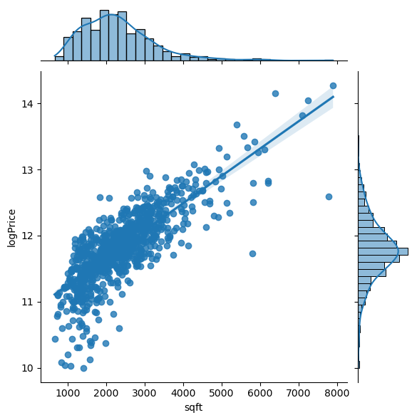

```python
sns.jointplot(x=data['sqft'], y=data['logPrice'], kind="reg")
plt.show()
```

#### OLS

Fit SLR by OLS assuming LSA 1-5

```python
reg1 = smf.ols(formula='logPrice ~ sqft', data=data).fit()
print(reg1.summary())
```

```
                            OLS Regression Results
==============================================================================
Dep. Variable:               logPrice   R-squared:                       0.625
Model:                            OLS   Adj. R-squared:                  0.624
Method:                 Least Squares   F-statistic:                     1637.
Date:                Fri, 08 Sep 2023   Prob (F-statistic):          1.44e-211
Time:                        13:37:35   Log-Likelihood:                -261.98
No. Observations:                 986   AIC:                             528.0
Df Residuals:                     984   BIC:                             537.8
Df Model:                           1
Covariance Type:            nonrobust
==============================================================================
                 coef    std err          t      P>|t|      [0.025      0.975]
------------------------------------------------------------------------------
Intercept     10.8373      0.026    420.188      0.000      10.787      10.888
sqft           0.0004   1.02e-05     40.462      0.000       0.000       0.000
==============================================================================
Omnibus:                      202.849   Durbin-Watson:                   2.027
Prob(Omnibus):                  0.000   Jarque-Bera (JB):              541.125
Skew:                          -1.058   Prob(JB):                    3.13e-118
Kurtosis:                       5.949   Cond. No.                     6.48e+03
==============================================================================

Notes:
[1] Standard Errors assume that the covariance matrix of the errors is correctly specified.
[2] The condition number is large, 6.48e+03. This might indicate that there are
strong multicollinearity or other numerical problems.
```

- The estimated relationship is: $\widehat{logPrice} = 10.8373 + 0.0004 \times \text{sqft}$
- The parameter estimates $\beta_0$ have SEs of 0.026 and $\beta_1$ $1.02 \times 10^{-5}$.
- The R-squared is 0.625, or 62.5%, which indicates a relatively strong fit. The SER is 0.316 as below shows the standard deviation of the residuals is 0.316.

```python
print(f"Standard deviation of the residuals: {round(reg1.mse_resid**0.5,3)}")
```

```
Standard deviation of the residuals: 0.316
```

Run the significant test for the slope separately by calling the `t_test` method of the model object `reg1`.

```python
hypothesis = 'sqft = 0'
t_test = reg1.t_test(hypothesis)  # 2-sided t-test  H0: beta_1 = 0
print(t_test)
```

```
                             Test for Constraints
==============================================================================
                 coef    std err          t      P>|t|      [0.025      0.975]
------------------------------------------------------------------------------
c0             0.0004   1.02e-05     40.462      0.000       0.000       0.000
==============================================================================
```

- The null hypothesis is: $H_0: \beta_1 = 0$ vs $H_1: \beta_1 \neq 0$,
- Since no direction is given in the question. $\alpha = 0.05$ as standard. The test statistics is $$t-stat = \frac{\hat{\beta_1}}{SE (\hat{\beta_1})} = \frac{0.0004}{1.02 \times 10^{-5}} = 40.462,$$ with 986 - 2 = 984 degrees of freedom.
- The two-sided p-value is $2 \times P(t_{984} > 40.462) = 0.000$. Since $p-val < \alpha= 0.05$ we reject the null and conclude at $95\%$ confidence level that there is a significant effect from the house living area to the logPrice.
- This test assumed all 5 LSA, including a constant error variance.

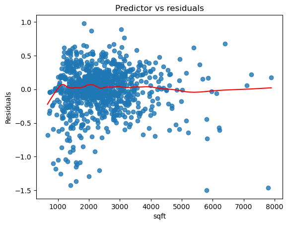

```python
data['resid'] = reg1.resid
lowess = sm.nonparametric.lowess
plt.figure()
sns.regplot(data=data, x='sqft', y='resid', fit_reg=False)
plt.xlabel('sqft')
plt.ylabel('Residuals')
plt.title('Predictor vs residuals')
z1 = lowess(reg1.resid, data['sqft'], frac=1./5)
plt.plot(z1[:,0],z1[:,1],'red')
plt.show()
```

### LAD

```python
mod = smf.quantreg(formula='logPrice ~ sqft', data=data)
reg_LAD = mod.fit(q=.5)
print(reg_LAD.summary())
```

```
                         QuantReg Regression Results
==============================================================================
Dep. Variable:               logPrice   Pseudo R-squared:               0.3899
Model:                       QuantReg   Bandwidth:                      0.1161
Method:                 Least Squares   Sparsity:                       0.5946
Date:                Fri, 08 Sep 2023   No. Observations:                  986
Time:                        13:37:35   Df Residuals:                      984
                                        Df Model:                            1
==============================================================================
                 coef    std err          t      P>|t|      [0.025      0.975]
------------------------------------------------------------------------------
Intercept     10.8703      0.024    447.895      0.000      10.823      10.918
sqft           0.0004    9.6e-06     42.780      0.000       0.000       0.000
==============================================================================

The condition number is large, 6.48e+03. This might indicate that there are
strong multicollinearity or other numerical problems.
```

```python
# Residuals using OLS and LAD
resid_OLS = reg1.resid
resid_LAD = reg_LAD.resid

# Fitted values using OLS and LAD
fit_OLS = reg1.fittedvalues
fit_LAD = reg_LAD.fittedvalues
```

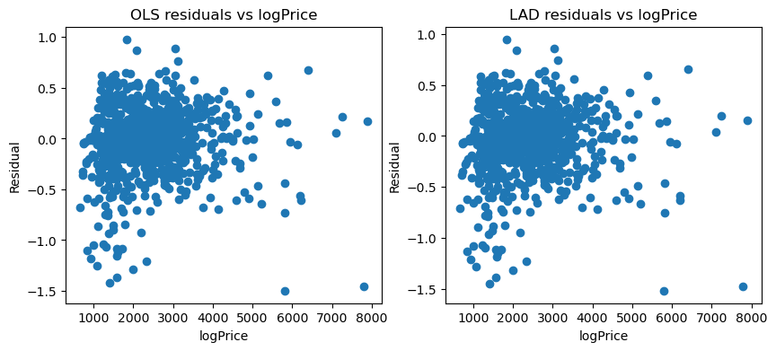

```python
fig, (ax1, ax2) = plt.subplots(1,2, figsize=(10,4))
ax1.scatter(data['sqft'], resid_OLS)
ax1.set_title("OLS residuals vs logPrice")
ax1.set_xlabel('logPrice')
ax1.set_ylabel('Residual')
ax2.scatter(data['sqft'], resid_LAD)
ax2.set_title("LAD residuals vs logPrice")
ax2.set_xlabel('logPrice')
ax2.set_ylabel('Residual')
plt.show()
```

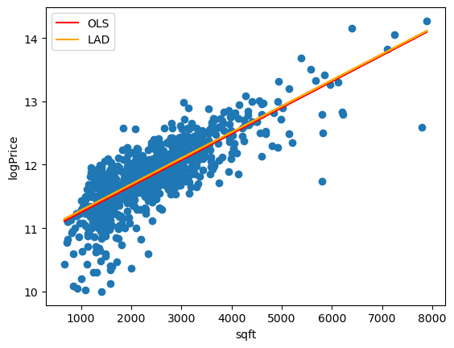

```python
plt.figure()
plt.scatter(data['sqft'], data['logPrice'])
plt.plot(data['sqft'], fit_OLS, color='red', label='OLS')
plt.plot(data['sqft'], fit_LAD, color='orange', label='LAD')
plt.xlabel('sqft')
plt.ylabel('logPrice')
plt.legend()
plt.show()
```

```python
hypothesis = 'sqft = 0'
t_test = reg1.t_test(hypothesis)  # 2-sided t-test  H0: beta_1 = 0
print(t_test)
```

```
                             Test for Constraints
==============================================================================
                 coef    std err          t      P>|t|      [0.025      0.975]
------------------------------------------------------------------------------
c0             0.0004   1.02e-05     40.462      0.000       0.000       0.000
==============================================================================
```

```python
hypothesis = 'sqft = 0'
t_test_LAD = reg_LAD.t_test(hypothesis)  # 2-sided LAD-based t-test  H0: beta_1 = 0
print(t_test_LAD)
```

```
                             Test for Constraints
==============================================================================
                 coef    std err          t      P>|t|      [0.025      0.975]
------------------------------------------------------------------------------
c0             0.0004    9.6e-06     42.780      0.000       0.000       0.000
==============================================================================
```

#### Comment

**OLS assumption**

1. Linearity: Since the $R^2$ is 62.5%, it indicates that LSA 1 is satisfied and this is a strong fit.
2. Exogeneity: The residual plot does not appear to display any clear patterns, nor does it display any clear changing variance (heteroskedasticity). A tendency of homoscedasticity is observed here. Hence, LSA 2 are pretty satisfied.
3. Independence: This assumption makes sure that the data pair are i.i.d. The sqft does not display any clear trend, but they have a local mean close to 0 and rarely deviating from that point during the whole period.
4. 4th moment exists: Outliers are controlled in this dataset by using the log transformation of price, which makes the dataset become normally distributed with rare outliers and avoid right-skewed as in normal price. Hence, LSA 4 is satisfied.
5. Constant error variance: This assumption is about homoscedasticity. Since the points are randomly distributed and there is no clear trends, we can assume that LSA 5 is well satisfied.

**LAD assumption**

The LAD estimator assumes:

1. Linearity: $Y = \beta_0 + \beta_1 X + \varepsilon$ is the true population linear model.
2. The median of $\varepsilon | X$ $=0$
3. Independence: The data pairs $Y_i, X_i$ are i.i.d.
4. Continuity of density: $p(Y_i|X_i)$ is a continuous function.
5. 1st absolute moment of Y exists: $E(|Y|)$ exists, i.e. is finite $< \infty$.
6. 2nd moment of X exists: $E(X^2)$ exists, i.e. is finite $< \infty$.
- The residual plot suggests that the typical residual is 0 for each value of $X = $ sqft, so assumptions 1 and 2 seem reasonable for this data. It makes sense when the living area has a great impact on the price of houses.
- Assumption 3 is satisfied as the data pairs are independent from each other.
- Assumption 4 requires a continuous density function. Since we do not know $p(Y|X)$, we will assume this to be true.
- Assumptions 5 and 6 are weaker compared to the moment requirements for OLS estimation. According to the log transformation as seen in the histogram and the boxplot, we can observe that the level of outliers is slighly extreme. Therefore, assumption 5 or 6 are satisfied.

**Slope test**

- The null hypothesis is $H_0: \beta_1 = 0$ vs $H_1: \beta_1 \neq 0$, since no direction is given in the question. $\alpha = 0.05$ (common choice).
- The OLS-based test statistics is $$t-stat = \hat{\beta_1} / SE (\hat{\beta_1}) = 0.0004 / 1.02 \times 10^{-5} = 40.462$$

  with 986 - 2 = 984 degrees of freedom.
- The p-value is $2P(t_{984} > 40.462) = 0.000$. Since $\text{p-val} < \alpha=0.05$, we reject the null (at $95\%$ confidence level) and conclude that there is a significant effect between the house living area and the price. This test assumed all 5 LSA, including a constant error variance.
- The LAD-based test statistics is $$t-stat = \hat{\beta_1} / SE (\hat{\beta_1}) = 0.0004 / 9.6 \times 10^{-6} = 42.780$$

  with 986 - 2 = 984 degrees of freedom.
- The p-value is $2P(t_{984} > 42.780) = 0.000$. Since $\text{p-val} < \alpha=0.05$ we reject the null (at $95\%$ confidence level) and conclude that there is a significant between the house living area and the price. This test assumed all 6 LAD assumptions above, but not a constant error variance.

## Task 4 (10 marks)

- Given the SLR model in Task 3, now we want to add one more predictor to improve the model fit using a MLR. Based on the analysis in Task 1, what is the second predictor you will use together with living area size to improve the model fit of the SLR?
- Fit the MLR model using OLS estimator. Report and comment on parameter estimates & significant test for slopes and model fitting. Is the model fit improved compared to the SLR model in Task 3?

Provide relevant analysis to support your answers.

#### Answer:

```python
reg2 = smf.ols(formula='logPrice ~ sqft + baths', data=data).fit()
print(reg2.summary())
```

```
                            OLS Regression Results
==============================================================================
Dep. Variable:               logPrice   R-squared:                       0.677
Model:                            OLS   Adj. R-squared:                  0.676
Method:                 Least Squares   F-statistic:                     1030.
Date:                Fri, 08 Sep 2023   Prob (F-statistic):          5.63e-242
Time:                        13:37:36   Log-Likelihood:                -187.81
No. Observations:                 986   AIC:                             381.6
Df Residuals:                     983   BIC:                             396.3
Df Model:                           2
Covariance Type:            nonrobust
==============================================================================
                 coef    std err          t      P>|t|      [0.025      0.975]
------------------------------------------------------------------------------
Intercept     10.5659      0.032    328.469      0.000      10.503      10.629
sqft           0.0003   1.34e-05     21.893      0.000       0.000       0.000
baths          0.2774      0.022     12.633      0.000       0.234       0.320
==============================================================================
Omnibus:                      153.432   Durbin-Watson:                   2.055
Prob(Omnibus):                  0.000   Jarque-Bera (JB):              323.497
Skew:                          -0.892   Prob(JB):                     5.67e-71
Kurtosis:                       5.166   Cond. No.                     9.78e+03
==============================================================================

Notes:
[1] Standard Errors assume that the covariance matrix of the errors is correctly specified.
[2] The condition number is large, 9.78e+03. This might indicate that there are
strong multicollinearity or other numerical problems.
```

```python
print(f"Standard deviation of the residuals: {round(reg2.mse_resid**0.5,3)}")
```

```
Standard deviation of the residuals: 0.293
```

#### Comment

Based on Task 1, we know that another predictor that also has a strong relationship with house prices which is **baths**.

**OLS method**

- The estimated relationship is: $\widehat{logPrice} = 10.5659 + 0.0003 \times \text{sqft} + 0.2774 \times \text{baths}$
- The parameter estimates $\beta_0$ have SEs of 0.032, $\beta_1$ = $1.34 \times 10^{-5}$ and $\beta_2$ = $0.022$.
- The R-squared is 0.677, or 67.7%, which indicates a moderately strong fit. This R-squared is higher than that of the simple linear regression from Task 3. Moreover, the adjusted R-squared of 0.676 suggests that the model is not overfitting after including another independent variables. The SER is 0.293 as above.

The effect of variable can be summarised as:

**Slope test** $\beta_1$

- The null hypothesis is $H_0: \beta_1 = 0$ vs $H_1: \beta_1 \neq 0$, since no direction is given in the question. $\alpha = 0.05$ (common choice).
- The OLS-based test statistics for $\hat{\beta_1}$ is $$t-stat = \hat{\beta_1} / SE (\hat{\beta_1}) = 0.0003 / 1.34 \times 10^{-5} = 21.893$$

**Slope test** $\beta_2$

- The null hypothesis is $H_0: \beta_2 = 0$ vs $H_1: \beta_2 \neq 0$, since no direction is given in the question. $\alpha = 0.05$ (common choice).
- The OLS-based test statistics for $\hat{\beta_2}$ is $$t-stat = \hat{\beta_1} / SE (\hat{\beta_1}) = 0.2774 / 0.02 = 12.633$$

Overall, this model is better than the SLR in predicting house price based on house living area and the number of baths in the house.

## Task 5 (10 marks)

- Repeat all steps in Task 4 with one additional predictor. What is the third predictor you will select?
- Fit the MLR model using OLS estimator. Report and comment on parameter estimates & significant test for slopes and model fitting.
- Is the model fit improved compared to the SLR model in Task 4?
- Discuss potential co-linearity issue between predictors in this model.

  Provide relevant analysis to support your answer.

#### Answer:

```python
reg3 = smf.ols(formula='logPrice ~ sqft + baths + bedrooms', data=data).fit()
print(reg3.summary())
```

```
                            OLS Regression Results
==============================================================================
Dep. Variable:               logPrice   R-squared:                       0.678
Model:                            OLS   Adj. R-squared:                  0.677
Method:                 Least Squares   F-statistic:                     689.4
Date:                Fri, 08 Sep 2023   Prob (F-statistic):          4.29e-241
Time:                        13:37:36   Log-Likelihood:                -186.24
No. Observations:                 986   AIC:                             380.5
Df Residuals:                     982   BIC:                             400.1
Df Model:                           3
Covariance Type:            nonrobust
==============================================================================
                 coef    std err          t      P>|t|      [0.025      0.975]
------------------------------------------------------------------------------
Intercept     10.6261      0.047    226.958      0.000      10.534      10.718
sqft           0.0003   1.52e-05     20.178      0.000       0.000       0.000
baths          0.2837      0.022     12.766      0.000       0.240       0.327
bedrooms      -0.0321      0.018     -1.769      0.077      -0.068       0.004
==============================================================================
Omnibus:                      157.878   Durbin-Watson:                   2.056
Prob(Omnibus):                  0.000   Jarque-Bera (JB):              336.136
Skew:                          -0.912   Prob(JB):                     1.02e-73
Kurtosis:                       5.204   Cond. No.                     1.34e+04
==============================================================================

Notes:
[1] Standard Errors assume that the covariance matrix of the errors is correctly specified.
[2] The condition number is large, 1.34e+04. This might indicate that there are
strong multicollinearity or other numerical problems.
```

```python
features = data[['sqft', 'baths', 'bedrooms']]
features = sm.add_constant(features)
vif = []
for i in range(3):
    vif.append(variance_inflation_factor(features.values, i+1))

vif
```

```
[2.5672946786981488, 2.054080739208188, 1.8667831937280228]
```

#### Comment

Another predictor that has a strong relationship with logPrice, along with sqft and baths is bedrooms.

**MLR**

The estimated multiple linear regression is:

\begin{align*} \widehat{\log(\text{Price})}&=\underset{(0.047)}{10.6261}+\,\underset{(1.52 \times 10^{-5})}{0.0003}\times\text{sqft} +\underset{(0.022)}{0.2837}\times\text{baths}+\underset{(0.018)}{-0.0321}\times\text{bedrooms} \end{align*}

The R-squared is 0.678, and the adjusted R-squared is 0.677.

- The parameter for sqft is the same as previous model. The parameter for baths is slighly increased compared to the previous one. The slope for bedrooms is -0.0321.
- The adjusted R-squared is 0.677, which has increased by 0.1% from the previous model. This suggests that adding $bedrooms$ to the model leads to this improvement.

The effect of variable can be summarised as:

**Slope test**

Significant test for $\beta_3$

**Multicollinearity**

Overall, this is a strong fit since we have witnessed an increase in $R^2$ and $\text{adj.} R^2$. However, this model exists multicollinearity, which makes it performs not as good as model 2.

## Task 6 (10 marks)

- Use three linear regression models you have developed so far to make price predictions for the 80 houses shown in the test data $D_{test}$, and compute the prediction errors measured in RMSE. Use OLS estimates for all models.
- Among three models you have developed, which model has lowest prediction error? Is it what you expected? Why or why not?

  Provide relevant analysis to support your answer.

#### Answer:

```python
d_test = pd.read_csv('house_price_data_test.csv')
d_test.columns = d_test.columns.str.lower()
d_test.loc[d_test['pool'] == 'No', 'pool'] = 0
d_test.loc[d_test['pool'] == 'Yes', 'pool'] = 1
d_test['logPrice'] = np.log(d_test['price'])
d_test
```

|  | price | sqft | bedrooms | baths | age | occupancy | pool | fireplace | waterfront | dom | logPrice |
| --- | --- | --- | --- | --- | --- | --- | --- | --- | --- | --- | --- |
| 0 | 112500 | 1836 | 3 | 2 | 25 | 1 | 0 | 0 | 0 | 45 | 11.630709 |
| 1 | 99900 | 1495 | 3 | 2 | 25 | 1 | 0 | 0 | 0 | 10 | 11.511925 |
| 2 | 149000 | 2876 | 3 | 2 | 45 | 1 | 0 | 1 | 0 | 2 | 11.911702 |
| 3 | 215000 | 1947 | 3 | 2 | 1 | 2 | 0 | 1 | 0 | 667 | 12.278393 |
| 4 | 206900 | 2694 | 3 | 2 | 2 | 1 | 0 | 1 | 0 | 115 | 12.239991 |
| ... | ... | ... | ... | ... | ... | ... | ... | ... | ... | ... | ... |
| 75 | 92000 | 1565 | 2 | 1 | 13 | 2 | 0 | 1 | 0 | 44 | 11.429544 |
| 76 | 74900 | 1603 | 3 | 1 | 45 | 2 | 0 | 1 | 0 | 10 | 11.223909 |
| 77 | 168750 | 2298 | 3 | 2 | 5 | 1 | 0 | 1 | 0 | 16 | 12.036174 |
| 78 | 42000 | 1489 | 3 | 1 | 35 | 2 | 0 | 0 | 0 | 12 | 10.645425 |
| 79 | 419900 | 5736 | 4 | 3 | 25 | 1 | 1 | 1 | 1 | 133 | 12.947772 |

80 rows × 11 columns

```python
prediction1 = reg1.predict(d_test)
prediction2 = reg2.predict(d_test)
prediction3 = reg3.predict(d_test)
```

```python
predictedPrice_1 = np.exp(prediction1)
predictedPrice_2 = np.exp(prediction2)
predictedPrice_3 = np.exp(prediction3)
```

```python
rmse_1 = np.sqrt(mean_squared_error(d_test['price'], predictedPrice_1))
rmse_2 = np.sqrt(mean_squared_error(d_test['price'], predictedPrice_2))
rmse_3 = np.sqrt(mean_squared_error(d_test['price'], predictedPrice_3))

print(rmse_1, rmse_2, rmse_3)
```

```
77228.24042003148 109554.44504783645 106763.92416982118
```

```python
resid1 = d_test['price'] - predictedPrice_1
resid2 = d_test['price'] - predictedPrice_2
resid3 = d_test['price'] - predictedPrice_3
```

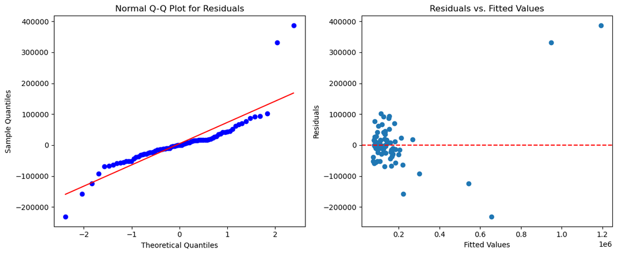

```python
fig, axes = plt.subplots(1, 2, figsize=(12, 5))

stat.probplot(resid1, dist="norm", plot=axes[0])
axes[0].set_title("Normal Q-Q Plot for Residuals")
axes[0].set_xlabel("Theoretical Quantiles")
axes[0].set_ylabel("Sample Quantiles")

axes[1].scatter(predictedPrice_1, resid1)
axes[1].set_xlabel("Fitted Values")
axes[1].set_ylabel("Residuals")
axes[1].set_title("Residuals vs. Fitted Values")
axes[1].axhline(y=0, color='r', linestyle='--')

plt.tight_layout()
plt.show()
```

The scatter plot between residual versus fitted value displays non-linearity

#### Comment

After the calculation of RMSE, we find out that model 1 seems to perform the best among the three since it has the lowest RMSE, with the RMSE of 77228.24. This is out of my expectation since in general, house price do not only depend on the living area, but also other factors i.e. number of bedrooms and baths in the house. However, based on what we have found out, there exists multicollinearity between different variables which leads to our MLR done in Task 4 and Task 5 have RMSE much greater than model 1 - a SLR model.

## Task 7 (10 marks)

- Write a brief report summarizing and discussing your findings and conclusions. For example, are the predictors useful to explain the house prices? What are about the performance of linear models used? Are the LSAs satisfied? If not, what should we do? etc.
- If you are a property investor, what are your strategies when buying houses to maximize the capital gain based on what you have discovered so far?

#### Answer:

From Task 1, we have found out that the most influential predictors in predicting house price is sqft - house living area, followed by number of bathrooms and bedrooms. Some other predictors such as waterfront, pool, fireplace or occupancy could also increase the house price a little bit. When we do MLR, adding predictors helps improving the $R^2$. Based on the model built from training data, we can see that model 2 is the best since $R^2$ is fairly high than model 1 and there is no collinearity as model 3. All LSAs for three models are satisfied.

When we do an experiment on the test data, since the RMSE for model 1 is the lowest, we can conclude that model 1 is the best model in predicting house price. After fitting the SLR and MLR using OLS and LAD, we can find a relatively strong relationship between house price, and house living area.

If I were a property investor, these could be the strategies when buying house to maximise the capital gain:

1. Potential house fits with characteristics: This could include looking for houses with the characteristics that we have outlined - large living areas. Since this features act as the main predictors of house price, investing in those houses will be benefit in long terms. Also, it is also beneficial to look at house with many features such as waterfront, pool or fireplace, which can increase the price.
2. Location: As we have observed in the EDA in task 1, we could see that house in good locations, i.e waterfront, always have price that are fairly higher than others. Hence, it is necessary to check the potential growth of the suburbs.
3. Renovation: It is also a good idea to invest in house with low price and start renovating later. This renovation could consists of increase the house living area, adding more bathrooms/bedrooms or making a pool. By doing this, we could increase the price of the house and thus, resulting in capital gain when they are on market.
4. Buy at low price, sale at high price: Look for houses that have observed price that are below the predicted price from the model. These house could be underestimated in values, hence, a bargain for investors if we invest in something similar and sell at higher price as we have predicted.